# HW4_Statistics

Ratkevich Ilya

15.05.2024

### Loading Libraries and Setting Up

### The Task

You are tasked with assessing the effects of grazing on the zoobenthos of rivers on Tasmania. The goal is to identify which environmental factors most influence changes in the composition of flora and fauna.

### EDA

An explanation of the variables found in the `Grazing_Magierowski_et_al_2015.xls` dataset:

### Fauna Data (`fauna` sheet)

This sheet likely contains species composition data, detailing the presence, absence, or abundance of various zoobenthos species at each site. The specific columns would be species names or codes, with corresponding values indicating their observed quantities or presence.

### Coordinates Data (`coord` sheet)

1. **Latitude**: The latitude coordinate of the sampling site.
2. **Longitude**: The longitude coordinate of the sampling site.
3. Additional columns might include other locational data relevant to mapping or spatial analysis.

### Raw Data (`raw` sheet)

This sheet probably contains the original, unprocessed data from which the `env` and `fauna` sheets were derived. It might include raw measurements and observations, with possible additional metadata.

### Explanation of Key Variables

- **Abstraction, Regulation, and Grazing**: These variables capture human activities that can impact aquatic ecosystems by altering water availability, flow regimes, and introducing pollutants or physical disturbances.
- **Fines, Temperature, Conductivity, AvgTurbidity, pH, Alkalinity, NitrateNitrite, DRP, N_total, P_total**: These are chemical and physical water quality parameters that influence habitat conditions for aquatic organisms.
- **AvgShading, AvgAlgae, Chl**: These variables describe biological and physical features affecting light availability and primary productivity in the water.
- **GrazingRank**: Provides a qualitative measure of the impact of grazing activities.

These variables collectively help assess the impact of environmental stressors, particularly grazing, on the composition and health of aquatic ecosystems.

### The Solution

#### Loading Data

```r
# Load the data from Excel sheets
fauna_data <- read_excel('Grazing_Magierowski_et_al_2015.xls', sheet = 'fauna')
environmental_data <- read_excel('Grazing_Magierowski_et_al_2015.xls', sheet = 'env')
```

#### Data Preparation

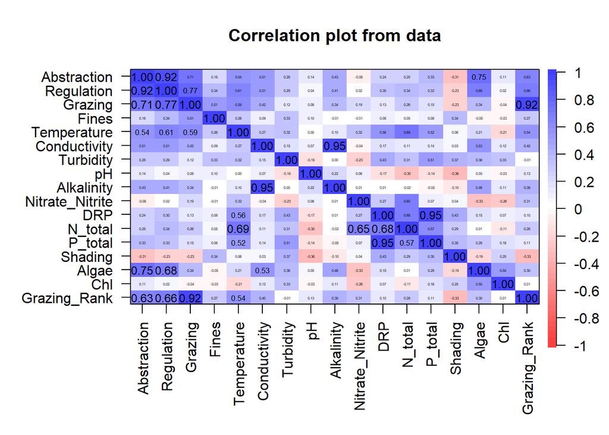

```r
# Merge environmental and fauna data, then remove rows with missing values
combined_data <- merge(environmental_data, fauna_data)

clean_data <- na.omit(combined_data)

#Normalize numerical data
env_data_log <- data.frame(clean_data)
env_data_log[,2:17] <- (clean_data[, 2:17])

#make grazing rank numerical to see correlation
env_data_log[,"GrazingRank"] <- as.numeric(as.factor(env_data_log[,"GrazingRank"]))
colnames(env_data_log)[4:18] <- c("Grazing","Fines","Temperature","Conductivity",
                                  "Turbidity","pH", "Alkalinity","Nitrate_Nitrite",
                                  "DRP","N_total","P_total","Shading","Algae","Chl",
                                  "Grazing_Rank"
                                  )

corPlot(env_data_log[,2:18], las=2)
```

Therefore, we can exclude: ‘Regulation’, ‘Grazing_Rank’, ‘DRP’, ‘Algae’, ‘Alcalinity’ to avoid multicollinearity.

### Canonical Correspondence Analysis (CCA)

```r
# Perform CCA
cca_model <- cca(env_data_log[,19:length(env_data_log)] ~ Abstraction + Grazing + Fines + Temperature +
                   Conductivity + Turbidity + pH + Nitrate_Nitrite +
                   N_total + P_total + Shading + Chl, data = env_data_log)

# Check variance inflation factors (VIF) and summary of the CCA model
vif.cca(cca_model)
```

```
##     Abstraction         Grazing           Fines     Temperature    Conductivity
##        4.645050        8.327308        5.930363        5.670468        2.056621
##       Turbidity              pH Nitrate_Nitrite         N_total         P_total
##        2.486335        2.832566        7.575805       12.996684        2.554847
##         Shading             Chl
##        5.553464        2.264980
```

```r
summary(cca_model)
```

```
##
## Call:
## cca(formula = env_data_log[, 19:length(env_data_log)] ~ Abstraction +      Grazing + Fines + Temperature + Conductivity + Turbidity +      pH + Nitrate_Nitrite + N_total + P_total + Shading + Chl,      data = env_data_log)
##
## Partitioning of scaled Chi-square:
##               Inertia Proportion
## Total           3.413     1.0000
## Constrained     2.248     0.6587
## Unconstrained   1.165     0.3413
##
## Eigenvalues, and their contribution to the scaled Chi-square
##
## Importance of components:
##                         CCA1   CCA2    CCA3    CCA4   CCA5    CCA6   CCA7
## Eigenvalue            0.4789 0.3707 0.30852 0.23304 0.2075 0.14994 0.1150
## Proportion Explained  0.1403 0.1086 0.09039 0.06828 0.0608 0.04393 0.0337
## Cumulative Proportion 0.1403 0.2489 0.33933 0.40761 0.4684 0.51234 0.5460
##                          CCA8    CCA9   CCA10   CCA11   CCA12     CA1     CA2
## Eigenvalue            0.10423 0.09226 0.08108 0.06219 0.04466 0.21957 0.16824
## Proportion Explained  0.03054 0.02703 0.02375 0.01822 0.01308 0.06433 0.04929
## Cumulative Proportion 0.57658 0.60361 0.62736 0.64559 0.65867 0.72300 0.77230
##                           CA3     CA4     CA5     CA6     CA7     CA8     CA9
## Eigenvalue            0.15997 0.14139 0.09843 0.08724 0.08373 0.06905 0.06296
## Proportion Explained  0.04687 0.04143 0.02884 0.02556 0.02453 0.02023 0.01845
## Cumulative Proportion 0.81917 0.86060 0.88944 0.91500 0.93953 0.95976 0.97821
##                          CA10     CA11
## Eigenvalue            0.04559 0.028787
## Proportion Explained  0.01336 0.008435
## Cumulative Proportion 0.99157 1.000000
##
## Accumulated constrained eigenvalues
## Importance of components:
##                         CCA1   CCA2   CCA3   CCA4    CCA5   CCA6    CCA7
## Eigenvalue            0.4789 0.3707 0.3085 0.2330 0.20751 0.1499 0.11502
## Proportion Explained  0.2130 0.1649 0.1372 0.1037 0.09231 0.0667 0.05116
## Cumulative Proportion 0.2130 0.3779 0.5152 0.6188 0.71114 0.7778 0.82900
##                          CCA8    CCA9   CCA10   CCA11   CCA12
## Eigenvalue            0.10423 0.09226 0.08108 0.06219 0.04466
## Proportion Explained  0.04637 0.04104 0.03606 0.02766 0.01986
## Cumulative Proportion 0.87537 0.91641 0.95247 0.98014 1.00000
```

[output cut: 360 more lines]

```
## Biplot scores for constraining variables
##
##                     CCA1     CCA2      CCA3      CCA4     CCA5     CCA6
## Abstraction      0.80726 -0.25877 -0.279295 -0.005792  0.14202  0.01362
## Grazing          0.56092 -0.18751 -0.403360  0.139165  0.39243  0.39278
## Fines            0.23493 -0.03457  0.020228  0.055830  0.13286  0.16596
## Temperature     -0.01305  0.01197 -0.709261  0.139883  0.48016 -0.10799
## Conductivity     0.64807  0.00346  0.363922  0.265562  0.43308 -0.17915
## Turbidity        0.04041  0.53768  0.009078  0.339153 -0.24878 -0.26900
## pH               0.44491 -0.13659  0.349427 -0.018305  0.11547 -0.06571
## Nitrate_Nitrite -0.45121 -0.34697 -0.066857 -0.267675  0.44152 -0.20817
## N_total         -0.35300 -0.14203 -0.364871 -0.054677  0.48863 -0.36881
## P_total         -0.12485 -0.37597 -0.309849  0.628908  0.04497 -0.38376
## Shading         -0.53033 -0.10226  0.237352  0.202187  0.19172 -0.18470
## Chl              0.02860 -0.15953  0.667776  0.293694 -0.18221  0.40624
```

### Visualization

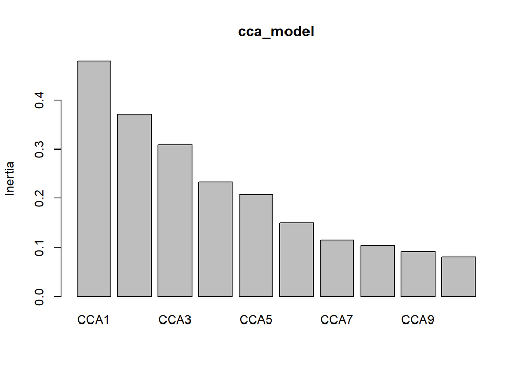

```r
# Scree plot
screeplot(cca_model, bstick = TRUE)
```

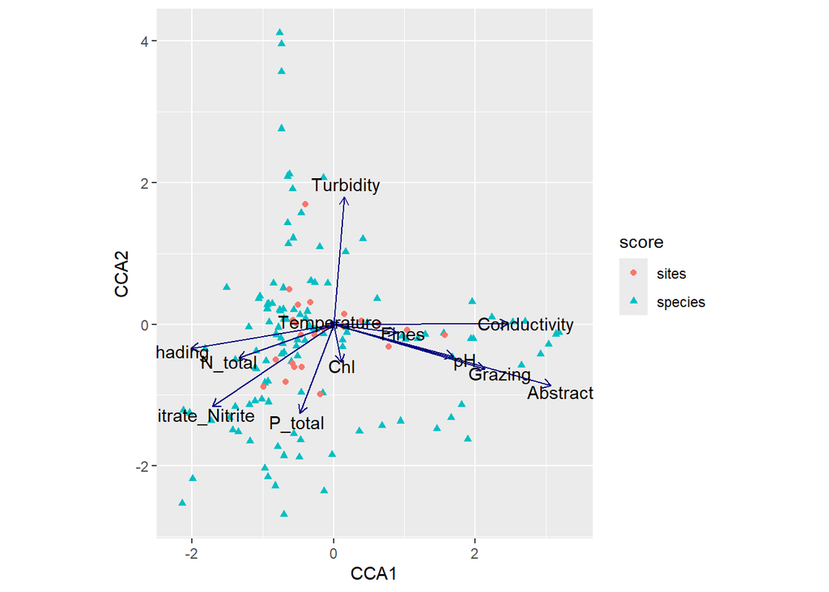

```r
# Plot CCA results
autoplot(cca_model, scaling = "sites")
```

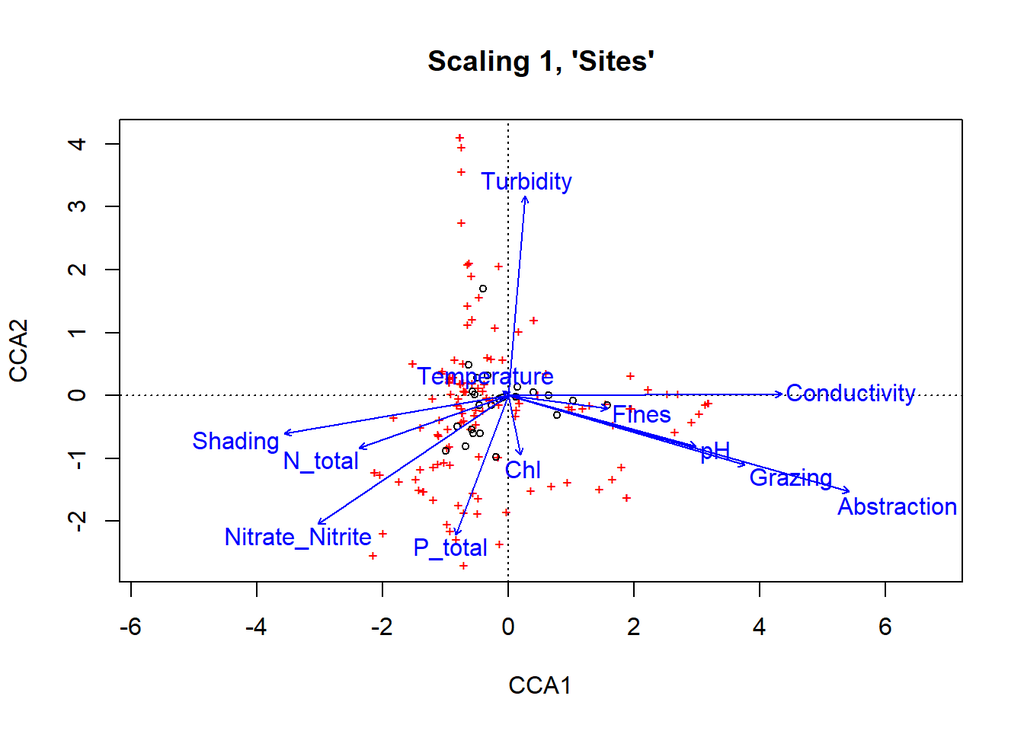

```r
plot(cca_model, scaling = "sites", main = "Scaling 1, 'Sites'")
```

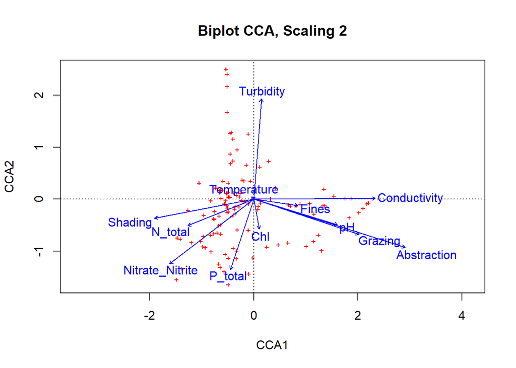

```r
plot(cca_model, scaling = 2, display = c("species", "cn"), main = "Biplot CCA, Scaling 2")
```

It can be seen that species differ very much by turbidity, P_total, Conductivity, etc. They spread depending on these variables, and we can build a model based on these observations

### Significance Testing

```r
# ANOVA for the CCA model

anova(cca_model)
```

```
## Permutation test for cca under reduced model
## Permutation: free
## Number of permutations: 999
##
## Model: cca(formula = env_data_log[, 19:length(env_data_log)] ~ Abstraction + Grazing + Fines + Temperature + Conductivity + Turbidity + pH + Nitrate_Nitrite + N_total + P_total + Shading + Chl, data = env_data_log)
##          Df ChiSquare      F Pr(>F)
## Model    12     2.248 1.7689  0.001 ***
## Residual 11     1.165
## ---
## Signif. codes:  0 '***' 0.001 '**' 0.01 '*' 0.05 '.' 0.1 ' ' 1
```

```r
anova(cca_model, by = "term")
```

```
## Permutation test for cca under reduced model
## Terms added sequentially (first to last)
## Permutation: free
## Number of permutations: 999
##
## Model: cca(formula = env_data_log[, 19:length(env_data_log)] ~ Abstraction + Grazing + Fines + Temperature + Conductivity + Turbidity + pH + Nitrate_Nitrite + N_total + P_total + Shading + Chl, data = env_data_log)
##                 Df ChiSquare      F Pr(>F)
## Abstraction      1   0.37879 3.5767  0.001 ***
## Grazing          1   0.14764 1.3940  0.162
## Fines            1   0.10741 1.0142  0.357
## Temperature      1   0.23402 2.2097  0.001 ***
## Conductivity     1   0.21860 2.0641  0.020 *
## Turbidity        1   0.24139 2.2793  0.002 **
## pH               1   0.09843 0.9294  0.476
## Nitrate_Nitrite  1   0.16439 1.5522  0.134
## N_total          1   0.10771 1.0170  0.414
## P_total          1   0.28258 2.6682  0.008 **
## Shading          1   0.10950 1.0339  0.393
## Chl              1   0.15758 1.4879  0.087 .
## Residual        11   1.16496
## ---
## Signif. codes:  0 '***' 0.001 '**' 0.01 '*' 0.05 '.' 0.1 ' ' 1
```

**Observation:** The model is significant (P = 0.001). The most important factors are `Abstraction`, `Temperature`, and `Turbidity`.

### Model Refinement

```r
# Refined CCA model
refined_cca_model <- cca(env_data_log[,19:length(env_data_log)] ~ Abstraction*Grazing*Conductivity + Fines +
                   Temperature + Turbidity*pH + Nitrate_Nitrite +
                   N_total*P_total + Shading*Chl, data = env_data_log)

# ANOVA for refined model
anova(refined_cca_model)
```

```
## Permutation test for cca under reduced model
## Permutation: free
## Number of permutations: 999
##
## Model: cca(formula = env_data_log[, 19:length(env_data_log)] ~ Abstraction * Grazing * Conductivity + Fines + Temperature + Turbidity * pH + Nitrate_Nitrite + N_total * P_total + Shading * Chl, data = env_data_log)
##          Df ChiSquare      F Pr(>F)
## Model    19   3.07276 1.9012  0.002 **
## Residual  4   0.34025
## ---
## Signif. codes:  0 '***' 0.001 '**' 0.01 '*' 0.05 '.' 0.1 ' ' 1
```

```r
anova(refined_cca_model, by = "term")
```

```
## Permutation test for cca under reduced model
## Terms added sequentially (first to last)
## Permutation: free
## Number of permutations: 999
##
## Model: cca(formula = env_data_log[, 19:length(env_data_log)] ~ Abstraction * Grazing * Conductivity + Fines + Temperature + Turbidity * pH + Nitrate_Nitrite + N_total * P_total + Shading * Chl, data = env_data_log)
##                                  Df ChiSquare      F Pr(>F)
## Abstraction                       1   0.37879 4.4531  0.001 ***
## Grazing                           1   0.14764 1.7356  0.089 .
## Conductivity                      1   0.23631 2.7780  0.010 **
## Fines                             1   0.11177 1.3139  0.210
## Temperature                       1   0.21196 2.4919  0.001 ***
## Turbidity                         1   0.24139 2.8378  0.001 ***
## pH                                1   0.09843 1.1572  0.285
## Nitrate_Nitrite                   1   0.16439 1.9326  0.059 .
## N_total                           1   0.10771 1.2662  0.180
## P_total                           1   0.28258 3.3221  0.001 ***
## Shading                           1   0.10950 1.2873  0.139
## Chl                               1   0.15758 1.8526  0.032 *
## Abstraction:Grazing               1   0.09816 1.1539  0.297
## Abstraction:Conductivity          1   0.11159 1.3119  0.148
## Grazing:Conductivity              1   0.11550 1.3579  0.105
## Turbidity:pH                      1   0.14786 1.7383  0.022 *
## N_total:P_total                   1   0.09370 1.1016  0.303
## Shading:Chl                       1   0.13285 1.5618  0.030 *
## Abstraction:Grazing:Conductivity  1   0.12506 1.4702  0.056 .
## Residual                          4   0.34025
## ---
## Signif. codes:  0 '***' 0.001 '**' 0.01 '*' 0.05 '.' 0.1 ' ' 1
```

**Observation:** The refined model is valid. `Turbidity`, `Abstraction`, `Temperature`, `Conductivity`, and `P_total` are the most significant factors. Other variables can be excluded for the final model.

### Final Model

```r
# Final CCA model
final_cca_model <- cca(env_data_log[,19:length(env_data_log)] ~ Abstraction + Grazing:Abstraction + Conductivity +
                   Temperature + Turbidity + P_total, data = env_data_log)

# ANOVA for final model
anova(final_cca_model)
```

```
## Permutation test for cca under reduced model
## Permutation: free
## Number of permutations: 999
##
## Model: cca(formula = env_data_log[, 19:length(env_data_log)] ~ Abstraction + Grazing:Abstraction + Conductivity + Temperature + Turbidity + P_total, data = env_data_log)
##          Df ChiSquare      F Pr(>F)
## Model     6     1.537 2.3214  0.001 ***
## Residual 17     1.876
## ---
## Signif. codes:  0 '***' 0.001 '**' 0.01 '*' 0.05 '.' 0.1 ' ' 1
```

```r
anova(final_cca_model, by = "term")
```

```
## Permutation test for cca under reduced model
## Terms added sequentially (first to last)
## Permutation: free
## Number of permutations: 999
##
## Model: cca(formula = env_data_log[, 19:length(env_data_log)] ~ Abstraction + Grazing:Abstraction + Conductivity + Temperature + Turbidity + P_total, data = env_data_log)
##                     Df ChiSquare      F Pr(>F)
## Abstraction          1   0.37879 3.4325  0.001 ***
## Conductivity         1   0.23735 2.1508  0.034 *
## Temperature          1   0.24533 2.2232  0.002 **
## Turbidity            1   0.20606 1.8673  0.016 *
## P_total              1   0.27597 2.5008  0.006 **
## Abstraction:Grazing  1   0.19351 1.7536  0.057 .
## Residual            17   1.87599
## ---
## Signif. codes:  0 '***' 0.001 '**' 0.01 '*' 0.05 '.' 0.1 ' ' 1
```

### Conclusion

The final analysis shows that `Abstraction`, `Conductivity`, ‘Temperature’, ‘Turbidity’ and `P_total` are the most significant factors influencing the zoobenthos composition in Tasmanian rivers.